# Data Science Capstone Project

Milestone Report

*Mick Sheahan* • *2018-08-10*

### Introduction

This report is a week 2 progress report of the overall Data Science Capstone project. It covers the initial tasks of loading and cleaning the data, carrying out some Exploratory Analysis and Modeling in preparation for the remainder of the project. It will form the basis for a prediction algorithm which can be utilised in an application that provides predictive text.

### Getting and cleaning the data

##### Data Loading and Processing

The data were downloaded from [here](https://d396qusza40orc.cloudfront.net/dsscapstone/dataset/Coursera-SwiftKey.zip) and unzipped.  
The data zipfiles contain 4 different languages - German, English, Finnish and Russian.  
For simplicity I will only use the English language files for this project.  
The code for data processing can be found [here](https://github.com/R3dCobbler/Coursera_Capstone-MilestoneReport/blob/master/data_processing.R).

##### Summary of the data

|  | File | Size | Lines | Words | Word_Characters | Avg_Characters | Max_Characters | AvgSentenceLength |
| --- | --- | --- | --- | --- | --- | --- | --- | --- |
| 1 | Blogs | 255.4 Mb | 899288 | 37570839 | 162464653 | 230 | 40833 | 42 |
| 2 | News | 257.3 Mb | 1010242 | 34494539 | 162227130 | 201 | 11384 | 34 |
| 3 | Twitter | 319 Mb | 2360148 | 30451128 | 125570616 | 69 | 140 | 13 |

##### Data Sampling

Finally combine all 3 text samples into one corpus. I am using the `quanteda` package for the majority of the text analylsis.

##### Tokenisation

The process here is to first of all consider how I want to clean and tokenise the corpus.  
* Remove profanities  
* Break into sentences  
* Remove URLs  
* Remove separators (white spaces, numbers and punctuation)

### Exploratory Analysis

In the exploration of the data I will attempt to understand the distribution of words and the relationship between the words in the corpora.  
Some things to consider:  
* Distributions of word frequencies  
* Frequencies of 2-grams and 3-grams in the dataset  
* How many unique words are needed in a frequency sorted dictionary to cover 50% of all word instances in the language?

##### Document-feature matrix

In the quanteda package, it is possible to create a document-feature matrix. Here are some basic details.  
I will use the N-gram model to work with the unigram, bigrams and trigrams, word associations of one, two and three words respectively.

Total words in the corpus

```
## [1] 2070942
```

Top 10 most frequent words and number

```
##    the     to    and      a     of      i     in   that     is     it
## 100828  60592  58543  51246  46947  46447  33283  25008  24497  23134
```

Sample texts from unigram

```
## tokens from 3 documents.
## text1.1 :
##  [1] "well"     "for"      "this"     "recipe"   "i"        "am"
##  [7] "forgoing" "the"      "textural" "desire"   "and"      "going"
## [13] "for"      "taste"    "all"      "within"   "keeping"  "down"
## [19] "calories" "and"      "fat"      "a"        "little"
##
## text1.2 :
## [1] "this"    "recipe"  "got"     "a"       "b"       "from"    "calorie"
## [8] "count"
##
## text2.1 :
##  [1] "other"    "film"     "roles"    "followed" "and"      "between"
##  [7] "his"      "world"    "travels"  "lancelot" "has"      "found"
## [13] "time"     "to"       "do"       "fifteen"  "featured" "parts"
## [19] "as"       "well"     "as"       "numerous" "musical"  "scores"
## [25] "in"       "calypso"  "tempo"    "for"      "the"      "major"
## [31] "studios"
```

Sample texts from bigram

```
## tokens from 3 documents.
## text1.1 :
##  [1] "well_for"        "for_this"        "this_recipe"
##  [4] "recipe_i"        "i_am"            "am_forgoing"
##  [7] "forgoing_the"    "the_textural"    "textural_desire"
## [10] "desire_and"      "and_going"       "going_for"
## [13] "for_taste"       "taste_all"       "all_within"
## [16] "within_keeping"  "keeping_down"    "down_calories"
## [19] "calories_and"    "and_fat"         "fat_a"
## [22] "a_little"
##
## text1.2 :
## [1] "this_recipe"   "recipe_got"    "got_a"         "a_b"
## [5] "b_from"        "from_calorie"  "calorie_count"
##
## text2.1 :
##  [1] "other_film"       "film_roles"       "roles_followed"
##  [4] "followed_and"     "and_between"      "between_his"
##  [7] "his_world"        "world_travels"    "travels_lancelot"
## [10] "lancelot_has"     "has_found"        "found_time"
## [13] "time_to"          "to_do"            "do_fifteen"
## [16] "fifteen_featured" "featured_parts"   "parts_as"
## [19] "as_well"          "well_as"          "as_numerous"
## [22] "numerous_musical" "musical_scores"   "scores_in"
## [25] "in_calypso"       "calypso_tempo"    "tempo_for"
## [28] "for_the"          "the_major"        "major_studios"
```

Sample texts from trigram

```
## tokens from 3 documents.
## text1.1 :
##  [1] "well_for_this"         "for_this_recipe"
##  [3] "this_recipe_i"         "recipe_i_am"
##  [5] "i_am_forgoing"         "am_forgoing_the"
##  [7] "forgoing_the_textural" "the_textural_desire"
##  [9] "textural_desire_and"   "desire_and_going"
## [11] "and_going_for"         "going_for_taste"
## [13] "for_taste_all"         "taste_all_within"
## [15] "all_within_keeping"    "within_keeping_down"
## [17] "keeping_down_calories" "down_calories_and"
## [19] "calories_and_fat"      "and_fat_a"
## [21] "fat_a_little"
##
## text1.2 :
```

[output cut: 19 more lines]

Sample texts from quadgram

```
## tokens from 3 documents.
## text1.1 :
##  [1] "well_for_this_recipe"         "for_this_recipe_i"
##  [3] "this_recipe_i_am"             "recipe_i_am_forgoing"
##  [5] "i_am_forgoing_the"            "am_forgoing_the_textural"
##  [7] "forgoing_the_textural_desire" "the_textural_desire_and"
##  [9] "textural_desire_and_going"    "desire_and_going_for"
## [11] "and_going_for_taste"          "going_for_taste_all"
## [13] "for_taste_all_within"         "taste_all_within_keeping"
## [15] "all_within_keeping_down"      "within_keeping_down_calories"
## [17] "keeping_down_calories_and"    "down_calories_and_fat"
## [19] "calories_and_fat_a"           "and_fat_a_little"
##
## text1.2 :
## [1] "this_recipe_got_a"    "recipe_got_a_b"       "got_a_b_from"
```

[output cut: 17 more lines]

Top 30 Single word frequencies

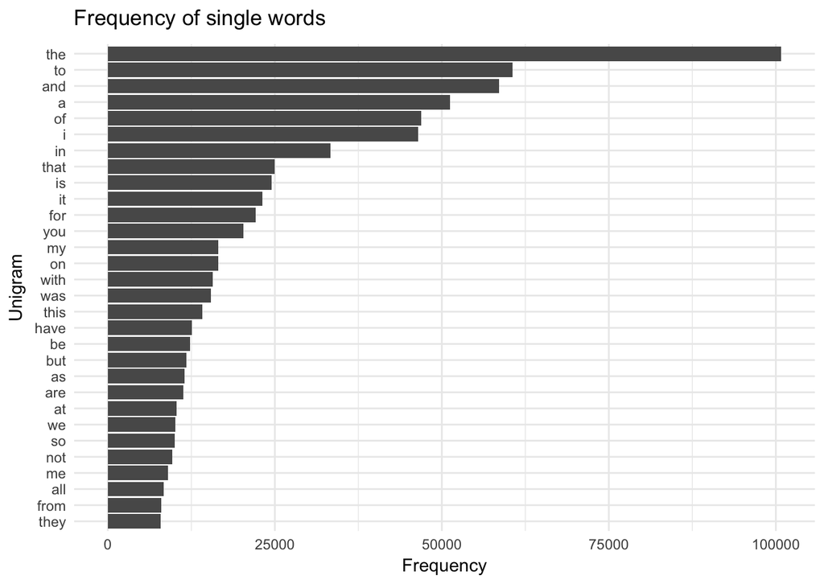

Top 30 2-gram frequencies

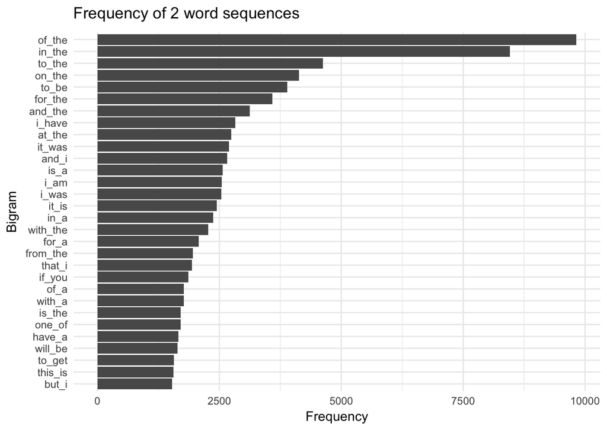

Top 30 3-gram frequencies

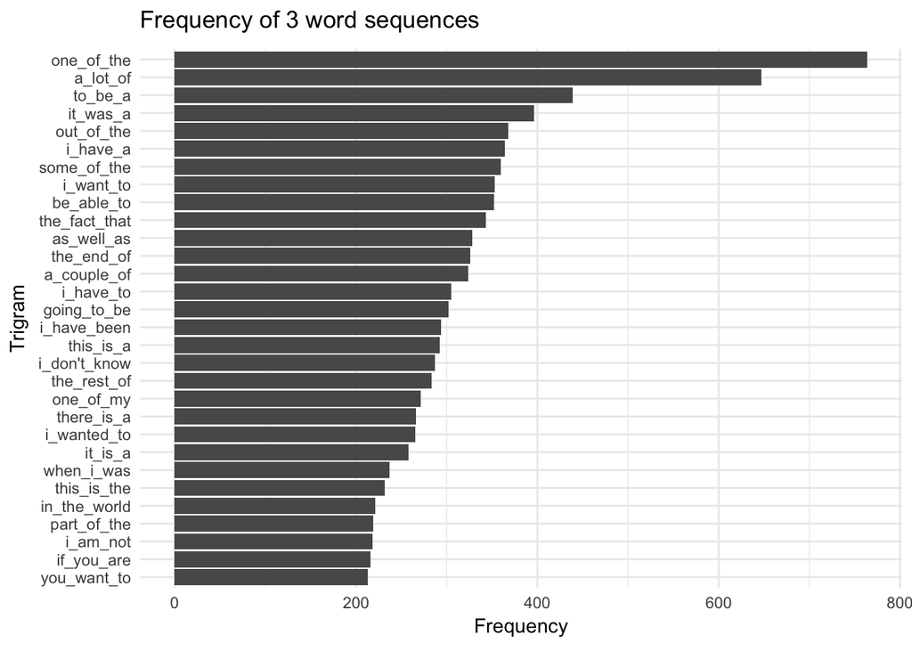

Top 30 4-gram frequencies

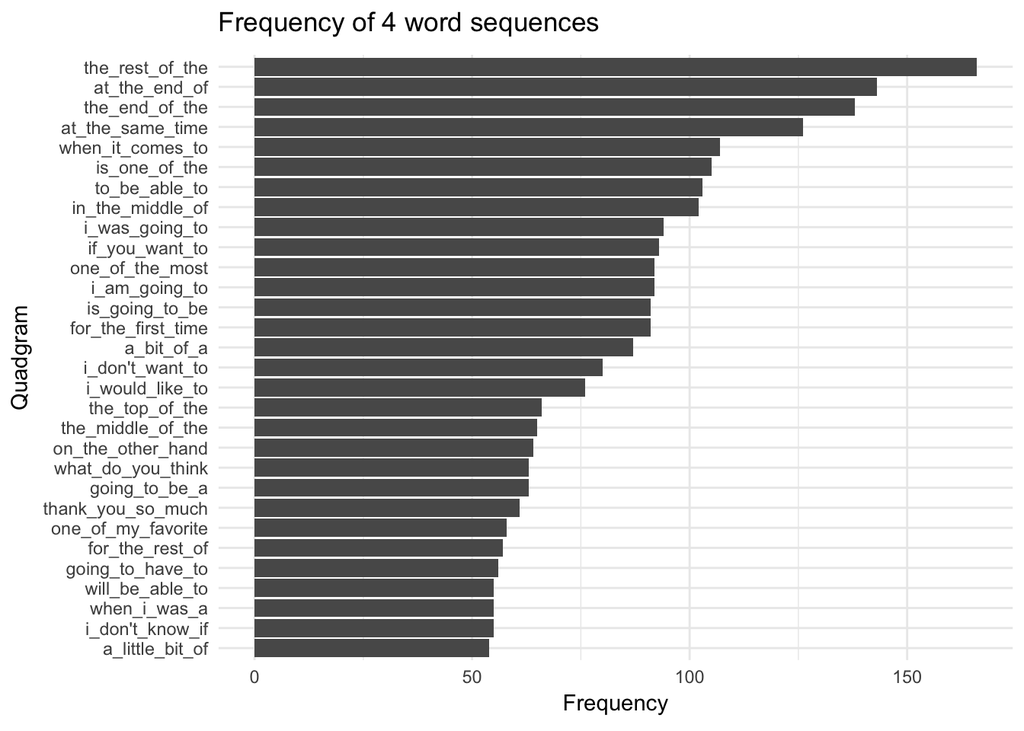

Word Cloud

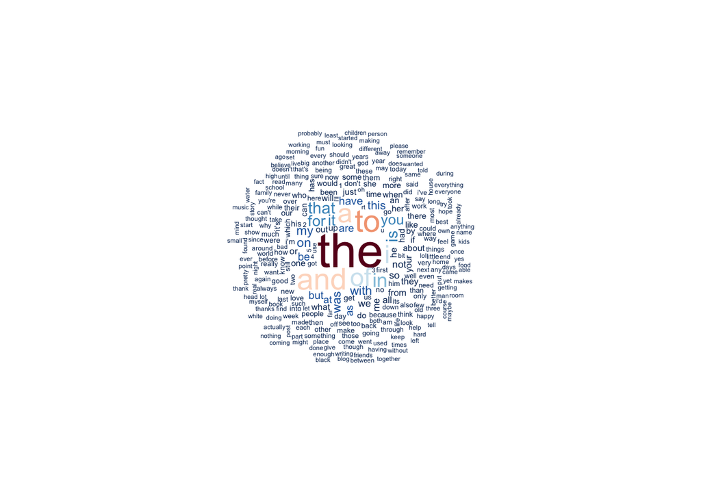

Semantic Network Analysis

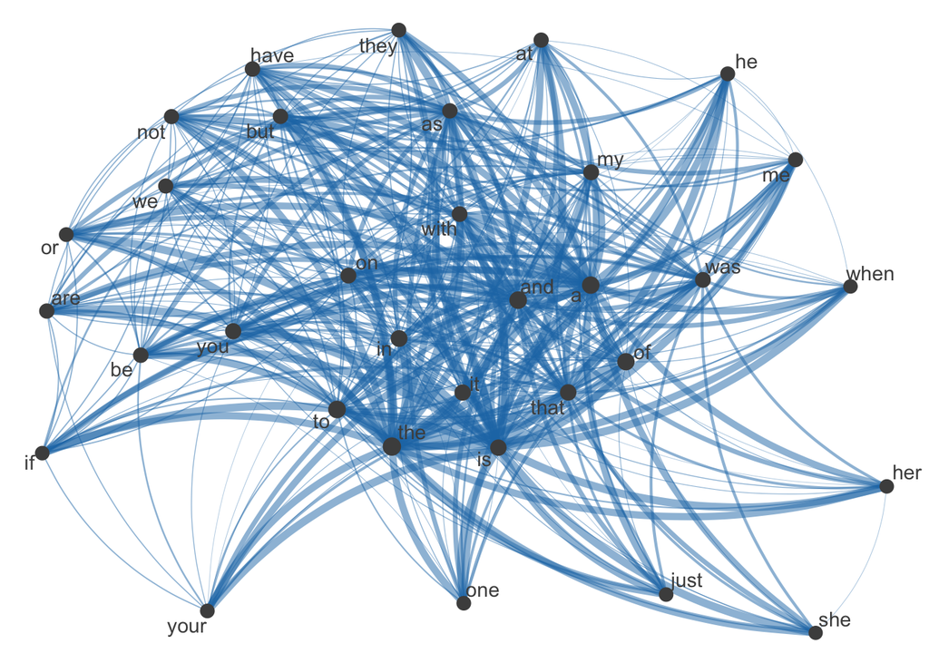

Coverage

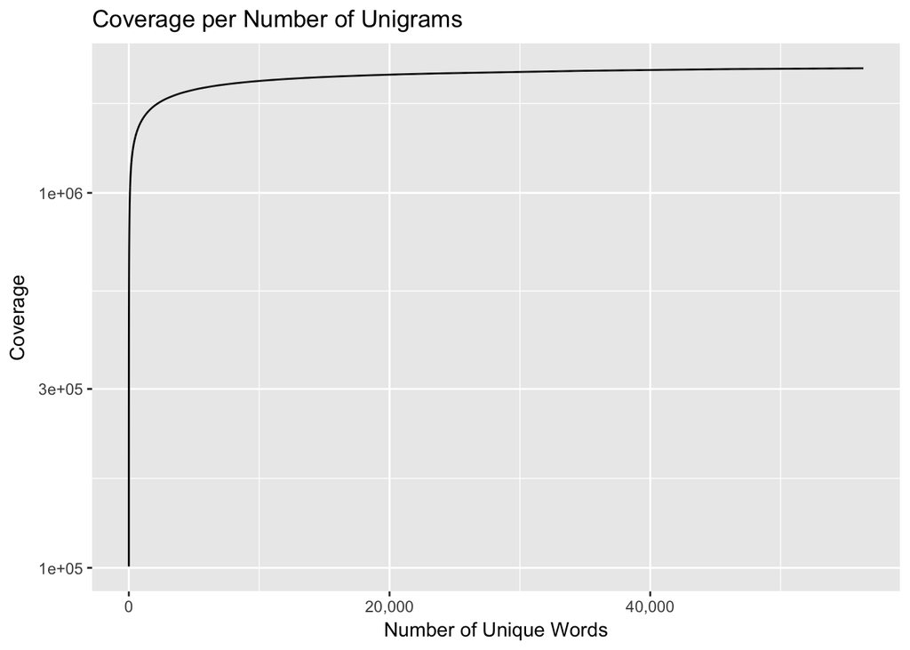

### Findings and next steps

- Very small numbers of words represent a large coverage of the overall corpus.
- Even with a sample size of 5% the processing time is very long. I should explore ways of speeding up the run time, perhaps further cleaning of the data.
- Carry out statistical analysis on the n-grams and DFMs. This can include lexical diversity, document/feature similarity, relative frequency analysis and collocation analysis.
- Build a predictive algorithm. Explore compound multi-word expressions and target word collocations. Trigrams could be a useful indicator of predicting next word.
- Deploy a Shiny application to showcase the prediction model. It should show a selection of predicted words depending on the word(s) entered by the end user. This would be a simple prototype to show basic functionality only.
- Measure the prediction accuracy of the app and compare with other industry predictive applications.